# Music Lyrics Entropy/Diversity Analysis (Supervised & Unsup.)

- Univariate/Multivariate Plotting
- Tree Based Song Popularity Predictor
- Artist-level PCA analysis for tips to commercial success

```r
#install.packages('tm')
# asdasd
#install.packages('textclean')
#install.packages('ggthemes')
#install.packages('ggpubr')
require(textclean)
require(tm)
require(dplyr)
require(stringr)
require(ggplot2)
library(ggthemes)
library(ggpubr)
require(gtools)
```

# 1. CSV READ AND LYRICS PREPROCESSING

- Simple pipeline with traditional NLP preprocessing.

The next few chunks are meant to be run if the user has created its own CSV and wishes to go through the preprocessing step by step. If one wishes to run the program with a dataframe that has been already preprocessed, please jump to part **2. FEATURE ENGINEERING**

```r
# df=read.csv('16k_songs_and_lyrics.csv')
#
#
# nrow(df)
#
# df = df %>%
#   rowwise( ) %>%
#   mutate(lyrics = gsub('\n', ' ', lyrics)) %>%
#   mutate(lyrics = tolower(lyrics)) %>%
#   mutate(lyrics = replace_contraction(lyrics, ignore.case = TRUE)    )%>%
#   mutate(lyrics = removePunctuation(lyrics))%>%
#   mutate(lyrics =   removeWords(x = lyrics, stopwords('en') )    )%>%
#   mutate(lyrics =   gsub('urlcopyembedcopy', '', lyrics) )%>%
#   mutate(lyrics =   gsub('embedshare', '', lyrics) )%>%
#   mutate(lyrics =   gsub('\\s+',' ', lyrics) )
#
# df = df %>%
#   mutate(lyrics_list = str_split(lyrics, ' ') )
#
# saveRDS(df, '16k_songs_and_lyrics_proc.rds')
#
# df <- readRDS('16k_songs_and_lyrics_proc.rds') # if we want to skip the preprocessing and read the formatted RDS
#
# names(df)
#
# ## Artists and Genre Preprocessing
#
# df_artists = read.csv('artists.csv')
#
# df_artists = df_artists %>%
#   mutate(artist_genres = gsub( pattern = '\\[','',  artist_genres )) %>%
#   mutate(artist_genres = gsub( pattern = '\\]','',  artist_genres )) %>%
#   mutate(artist_genres = gsub( pattern = '\'','',  artist_genres )) %>%
#   mutate(artist_genres = gsub( pattern = '\\s+','',  artist_genres )) %>%
#   mutate(artist_genres_list = str_split(artist_genres, ',')) %>%
#   mutate(artist_genres_list = lapply(artist_genres_list, trimws ))
#
# df_artists$artist_genres_list[16]
#
# genres = c()
#
# for (i in df_artists$artist_genres_list ){
#   genres = append(genres, i)
# }
# genres_freq = as.data.frame(table(genres[!genres %in% '']))
#
# genres_freq %>%
#   arrange(desc(Freq)) %>%
#   top_n(10)
#
# genre_standard = function(v)
# {
#   ifelse(v %in% c('rock', 'classicrock', 'albumrock', 'modenrock'),
#          'rock',
#          ifelse(v %in% c('pop', 'dancepop', 'poprock',
#                          'poprap', 'classicukpop'),
#                 'pop',
#                 ifelse( v %in% c('rap', 'trap', 'hiphop', 'r&b'),
#                         'rap',
#                         ifelse(v  %in% c('alernativemetal', 'hardrock', 'metal', 'numetal'),
#                                'metal',
#                                ifelse(v %in% c('newwavepop', 'folkrock', 'alternativerock',
#                                                'indiepop', 'indierock'),
#                                       'indie',
#                                       ifelse(v %in% c('disco', 'edm'),
#                                              'disco/edm',
#                                              'others'))))  ))
# }
#
#
# df_artists = df_artists %>%
#   mutate(genre_standarized = lapply(artist_genres_list, genre_standard) )
#
# df_artists = df_artists %>%
#   rowwise() %>%
#   mutate(main_genre =
#            ifelse('disco/edm' %in% genre_standarized, 'disco/edm',
#                   ifelse('indie' %in% genre_standarized, 'indie',
#                          ifelse('metal' %in% genre_standarized, 'metal',
#                                 ifelse('rap' %in% genre_standarized, 'rap',
#                                        ifelse('pop' %in% genre_standarized, 'pop',
#                                               ifelse('rock' %in% genre_standarized, 'rock', 'others'
#                                               )))))))
#
#
# #df_artists = df_artists %>% transmute(main_genre = main_genre[[1]])
# df_artists = df_artists[!duplicated(df_artists),]
#
#
# dim(df)
# #we paste the artists and genres to the main dataframe to finish with the preprocessing.
# df_merged = merge(x = df, y = df_artists, by = "artist_id",
#                   all.x = TRUE)
#
#
#
# saveRDS(df_merged, '16k_sngs_lyr_art_gnr.rds')
```

# 2. FEATURE ENGINEERING

- Run since this step to load an already preprocessed dataframe and skip 20 minutes of preprocessing
- Feature engineering includes creation of ratio features like words-per-minutes, words-per-unique, etc.
- We also create a formatted decade column

```r
# |v|v|v| start from here to skip  |v|v|v|
# |v|v|v| 20 mins of preprocessing |v|v|v|
df <- readRDS('16k_sngs_lyr_art_gnr.rds')


df = df %>%
  rowwise() %>%
  mutate(n_words = length(lyrics_list)) %>%
  mutate(n_unique = length(unique(lyrics_list)))

df = df[df$n_words<2000,] # only songs below 2000

df$duration_minutes  = df$duration_ms/60000
df$unique_per_minute = df$n_unique/df$duration_minutes
df$words_per_minute = df$n_words/df$duration_minutes
df$words_per_unique = df$n_words/df$n_unique

df = df %>% mutate(year = substr(track_release_date,1,4))
df$year = as.factor(df$year)
df$year_num = as.numeric(as.character(df$year))

df = df %>% mutate(decade =  paste(substr(year,3,3), '0', sep=''))
df = df[!df$decade == 'NA0',]
df$decade <- factor(df$decade, levels = c('50','60','70','80','90','00','10','20'))
df = df[df$decade != '50', ] # we filter 50s because its too few songs

attach(df)
```

# 3. VISUALIZATIONS

## 3.1. UNIVARIATE VISUALIZATIONS

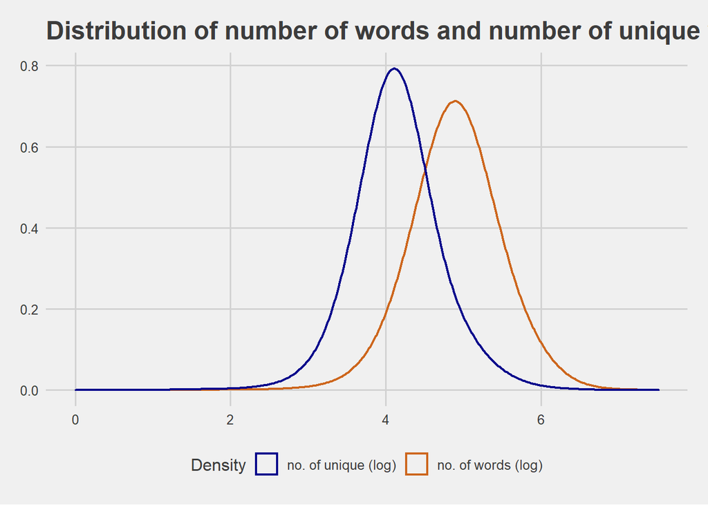

```r
df=  df[df$duration_minutes < 15, ]
df=  df[df$words_per_minute < 250, ]
df$popular = ifelse(df$track_popularity>0, 1, 0 )
df_popular = df[df$popular == 1 , ]

attach(df_popular)

ggplot(df) +
  geom_density( aes(x = log(n_words), color = 'no. of words (log)'), adjust=5, size=0.8) +
  geom_density( aes(x = log(n_unique), color = 'no. of unique (log)'), adjust=5 , size=0.8) +
  scale_colour_manual("Density", values = c("blue4", "chocolate3") ) +
  labs(title = 'Distribution of number of words and number of unique words (smoothed)') +
  xlab('Variables') +
  ylab('Density')  + theme_fivethirtyeight()
```

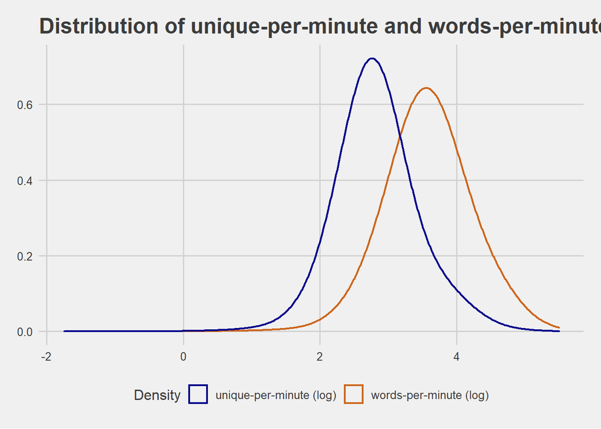

```r
ggplot(df) +
  geom_density( aes(x = log(words_per_minute) , color = 'words-per-minute (log)'), adjust=5, size = 0.8) +
  geom_density( aes(x = log(unique_per_minute), color = 'unique-per-minute (log)'), adjust=5, size=0.8) +
  scale_colour_manual("Density", values = c("blue4", "chocolate3") ) +
  labs(title = 'Distribution of unique-per-minute and words-per-minute (smoothed)') +
  xlab('Variables') +
  ylab('Density')  + theme_fivethirtyeight()
```

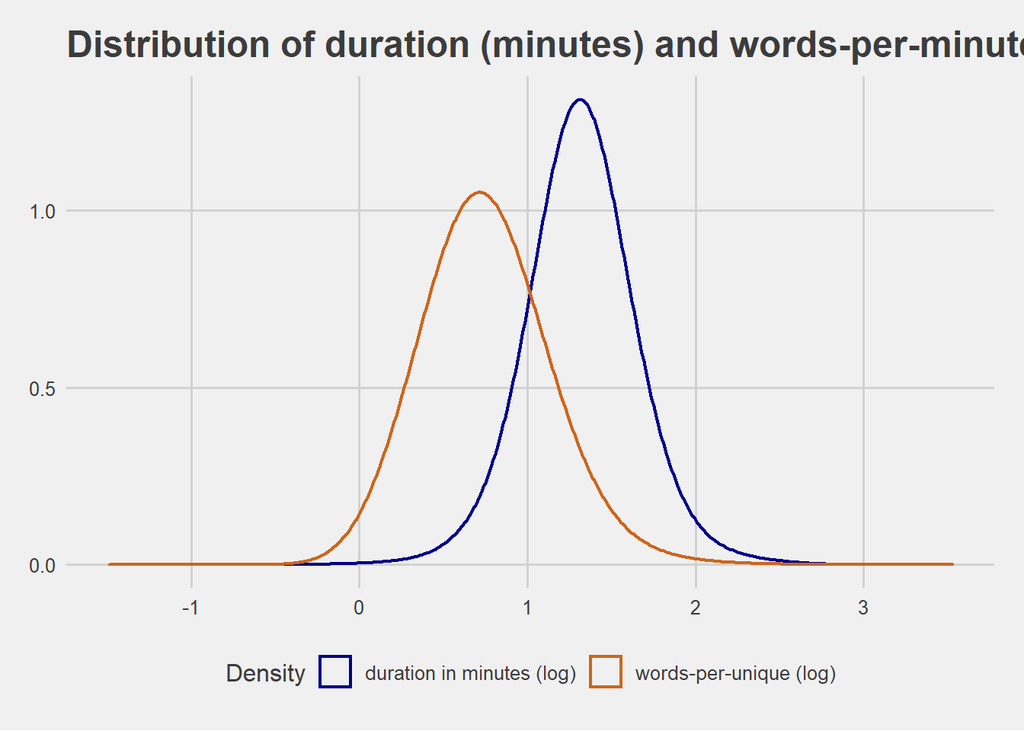

```r
ggplot(df) +
  geom_density( aes(x = log(duration_minutes) , color = 'duration in minutes (log)'), adjust=5, size = 0.8) +
  geom_density( aes(x = log(words_per_unique), color = 'words-per-unique (log)'), adjust=5, size=0.8) +
  scale_colour_manual("Density", values = c("blue4", "chocolate3") ) +
  labs(title = 'Distribution of duration (minutes) and words-per-minute (smoothed)') +
  xlab('Variables') +
  ylab('Density')  + theme_fivethirtyeight()
```

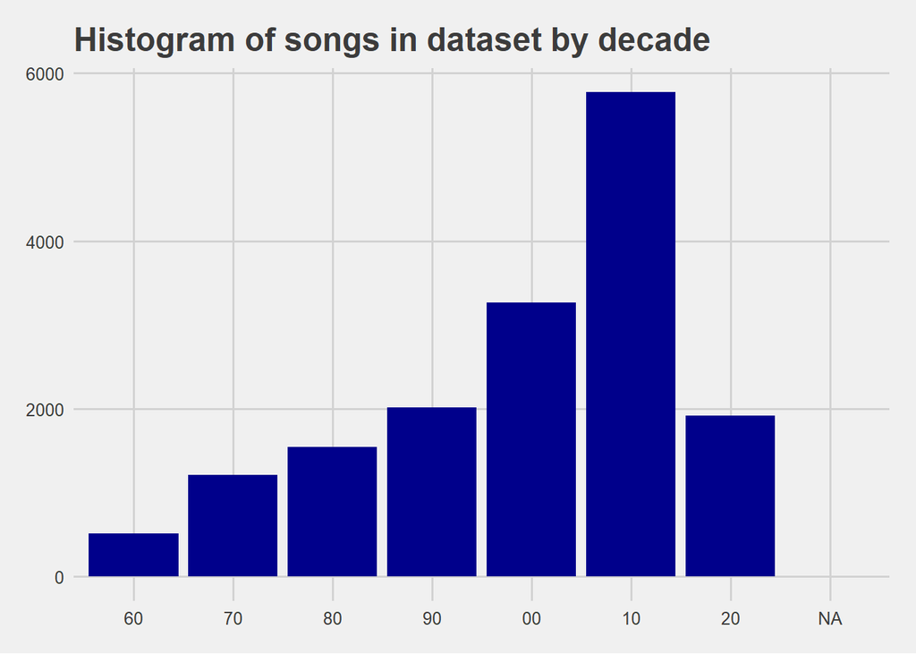

```r
df %>%
  ggplot(aes(x = decade)) +
  geom_histogram(stat='count', fill='blue4') +
  labs(title='Histogram of songs in dataset by decade') +
  xlab('Decades') +
  ylab('Frequency')  +theme_fivethirtyeight()
```

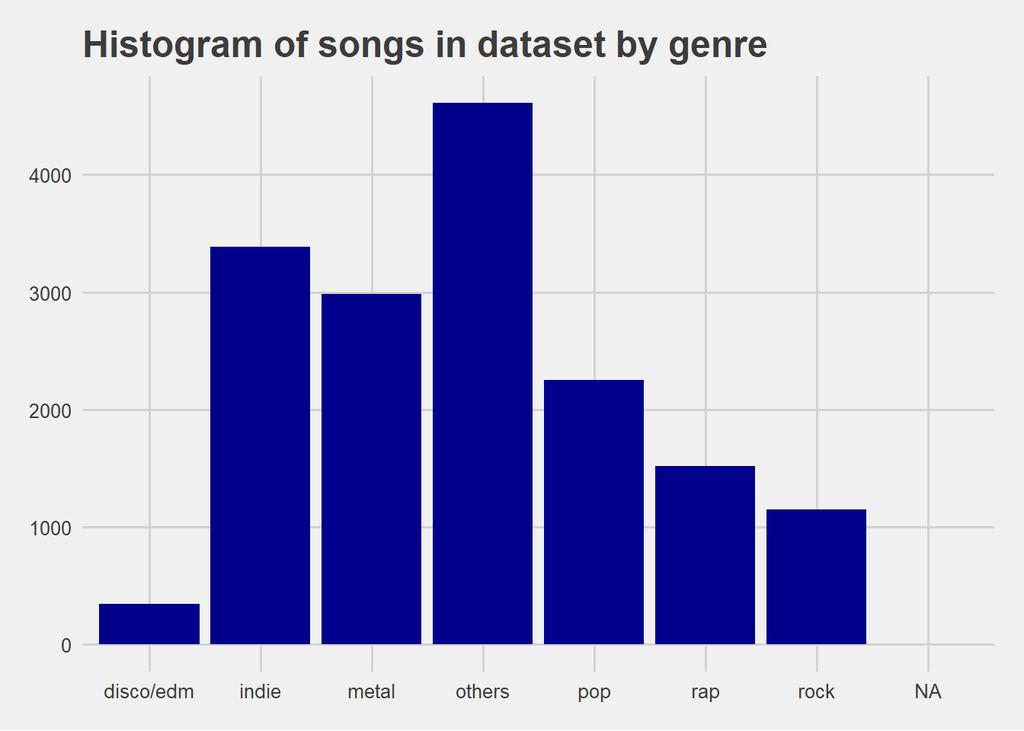

```r
df %>%
  ggplot(aes(x = main_genre)) +
  geom_histogram(stat='count', fill='blue4') +
  labs(title='Histogram of songs in dataset by genre') +
  xlab('Decades') +
  ylab('Frequency')  +theme_fivethirtyeight()
```

## 3.2. MULTIVARIATE VISUALIZATIONS

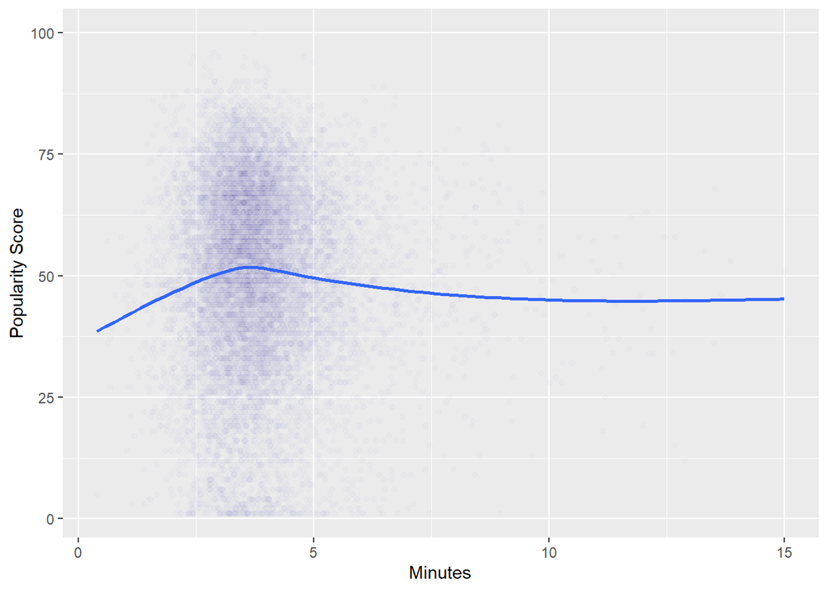

```r
df=  df[df$duration_minutes < 15, ]
df=  df[df$words_per_minute < 250, ]
df$popular = ifelse(df$track_popularity>0, 1, 0 )
df_popular = df[df$popular == 1 , ]
attach(df_popular)


df_popular %>%
  ggplot(aes(x = duration_minutes, y = track_popularity)) +
  geom_point(alpha=0.01, color='blue4') +
  geom_smooth( se = FALSE)+
  xlab('Minutes') + ylab('Popularity Score') +
  labs('Correlation between minutes of a song and its popularity')
```

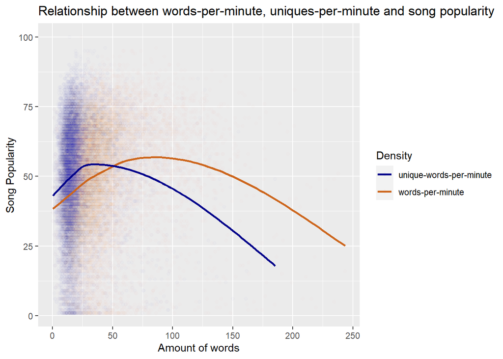

```r
df_popular %>%
  ggplot(aes(y = track_popularity )) +
  geom_point( aes(x = words_per_minute, color = 'words-per-minute'), alpha=0.01) +
  geom_point( aes(x = unique_per_minute, color='unique-words-per-minute'), alpha = 0.01) +
  geom_smooth( aes(x = words_per_minute, color = 'words-per-minute'), se=FALSE) +
  geom_smooth( aes(x = unique_per_minute, color='unique-words-per-minute'), se=FALSE) +
  scale_colour_manual("Density", values = c("blue4", "chocolate3") ) +
  labs(title='Relationship between words-per-minute, uniques-per-minute and song popularity ') +
  xlab('Amount of words') +
  ylab('Song Popularity')
```

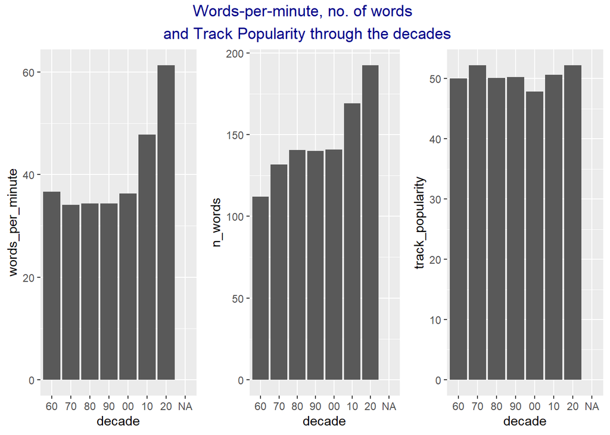

```r
plot1 = df_popular %>%
  ggplot(aes(y = words_per_minute, x = decade)) +
  geom_bar(stat = 'summary')

plot2 = df_popular %>%
  ggplot(aes(y = n_words, x = decade)) +
  geom_bar(stat = 'summary')

plot3 = df_popular %>%
  ggplot(aes(y = track_popularity, x = decade)) +
  geom_bar(stat = 'summary') # tracks are popular among all decades so we can analyze all of them

plot <- ggarrange(plot1,
                  plot2, plot3,
                  ncol=3, nrow=1,
                  legend="bottom")


annotate_figure(plot, top = text_grob("Words-per-minute, no. of words \n and Track Popularity through the decades",
                                      color = 'blue4',
                                      size = 13))
```

### Entropy measure: Words-per-unique

This new feature measures how many words exist in a lyric for each ``unique’’ one. The higher it is, the more repetitive it is. For example, a WPU of 4 would tell us that the singer will only say a new term every 4 given words.

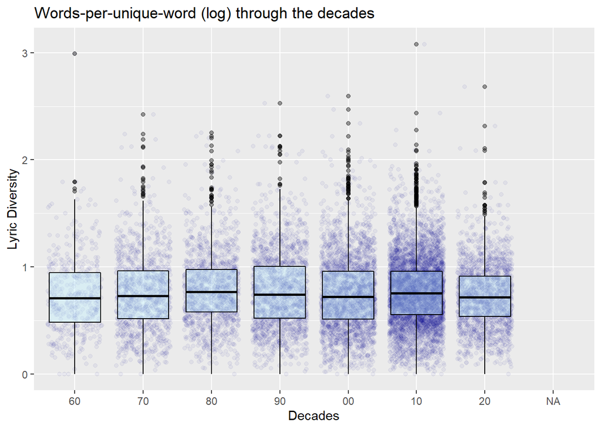

```r
ggplot(data = df_popular, aes(x=decade,y=log(words_per_unique) )) +
  geom_jitter(alpha=0.05, color='blue4') +
  geom_boxplot(fill="lightblue1",color="black",alpha=0.4) +
  labs(title='Words-per-unique-word (log) through the decades') +
  xlab(label='Decades') +
  ylab(label ='Lyric Diversity')
```

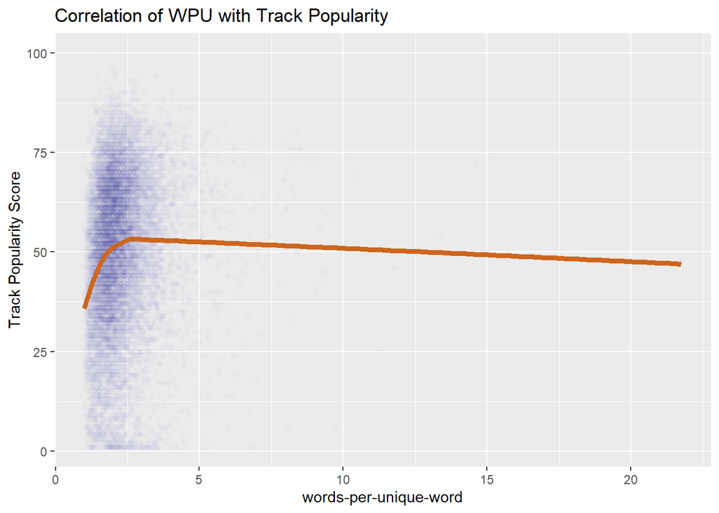

```r
df_popular %>%
  ggplot(aes(x = words_per_unique, y = track_popularity)) +
  xlab('words-per-unique-word') +
  ylab('Track Popularity Score') +
  labs( title = 'Correlation of WPU with Track Popularity') +
  geom_point(alpha = 0.01, color='blue4') +
  geom_smooth( se=FALSE, color = 'chocolate3', size = 1.7)
```

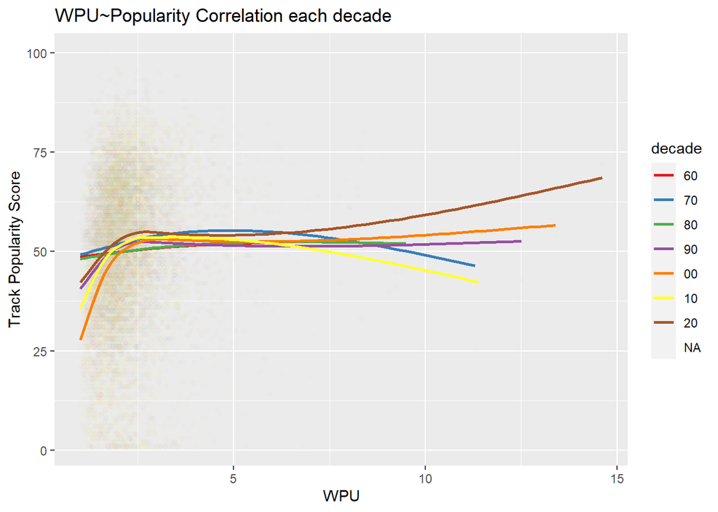

```r
df_popular[df_popular$words_per_unique<15,] %>%
  ggplot(aes(x = words_per_unique, y = track_popularity, color=decade)) +
  geom_point( alpha = 0.01) +
  geom_smooth( se = F, size=1) +
  xlab('WPU') +
  ylab('Track Popularity Score')+
  labs(title = 'WPU~Popularity Correlation each decade') +
  scale_colour_brewer( palette = "Set1")
```

Insight: In the 70s, people penalized repetitive songs (high WPU tended to reduce your popularity). This behavior has switched decreased over time.

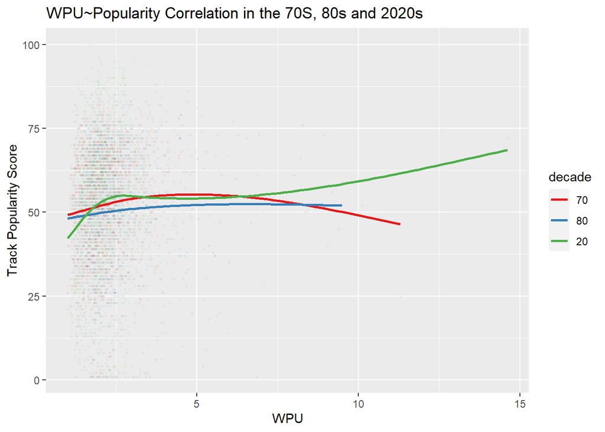

```r
df_popular[df_popular$decade %in% c('70' , '80', '20'), ]  %>%
  ggplot(aes(x = words_per_unique, y = track_popularity, color=decade)) +
  geom_point( alpha = 0.05, size=0.5) +
  geom_smooth( se = F, size=1)+ xlab('WPU') +
  ylab('Track Popularity Score')+
  labs(title = 'WPU~Popularity Correlation in the 70S, 80s and 2020s') +
  scale_colour_brewer( palette = "Set1")
```

```r
df_popular$popularity_group = quantcut(df_popular$track_popularity, q = 3,
                                       labels = c('not popular', 'average','very popular' ))
```

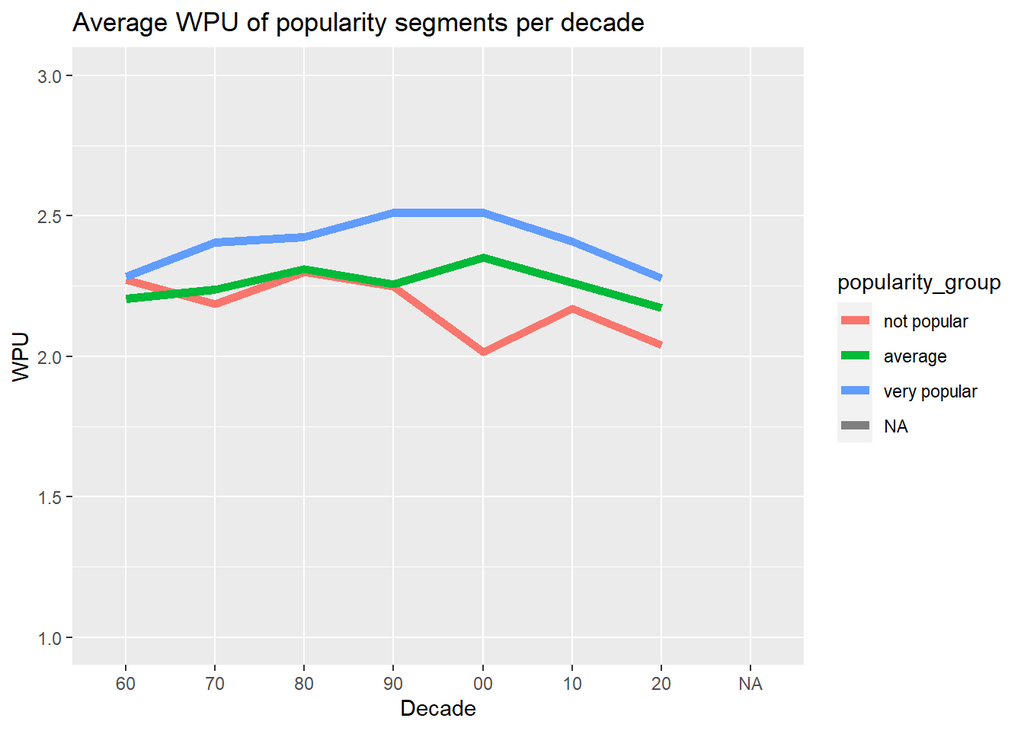

```r
df_popular %>%
  group_by(decade, popularity_group) %>%
  summarise(Mean_entropy = mean(words_per_unique)) %>%
  ggplot(aes(x = decade, y = Mean_entropy, color = popularity_group, group=popularity_group)) +
  geom_line(size=2) +
  ylim(1,3) +
  ylab('WPU') +
  xlab('Decade') +
  labs( title = 'Average WPU of popularity segments per decade')
```

Insight: in almost every decade, the top songs, those who belong to the 33% most popular in their decade, had a higher entropy (more repetitive) than the rest. Meaning that repetition of lyrics tends to be more noticeable on hits that not-hits. Causal relationship cannot be established.

### Genre, Decade & Lyrics’ Entropy analysis

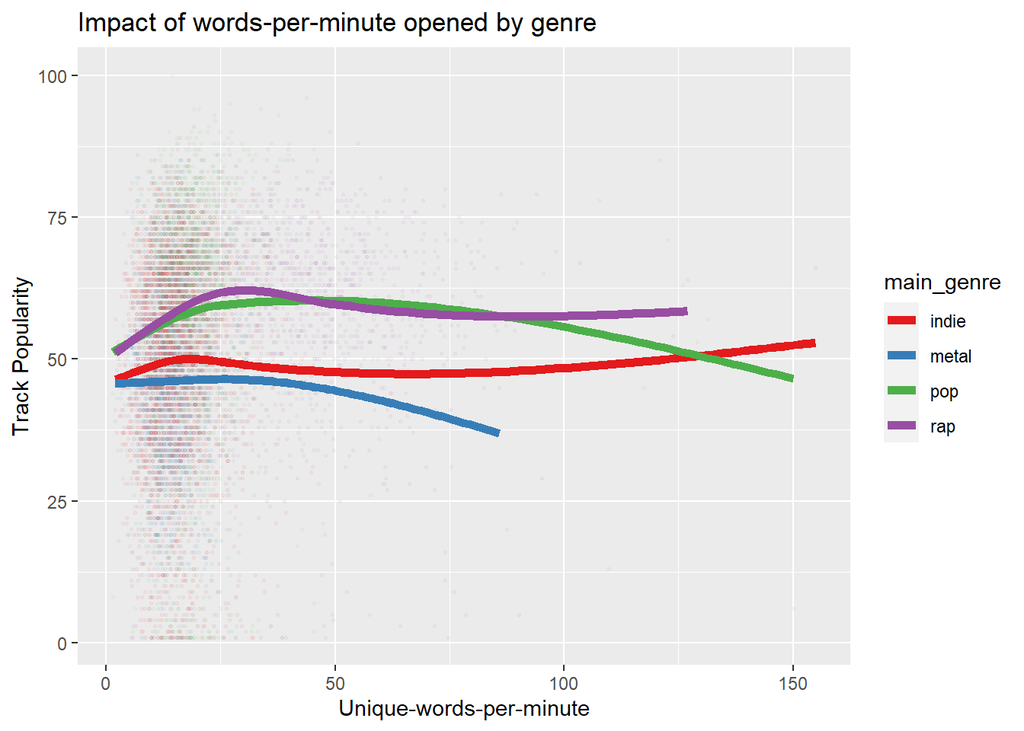

```r
df_popular = df_popular[!is.na(df_popular$words_per_unique),]

attach(df_popular)

#names(df_popular)
#table(main_genre)


df_popular[df_popular$main_genre %in% c('indie', 'metal', 'pop', 'rap' ),]  %>%
  ggplot(aes(x = unique_per_minute, y = track_popularity, color=main_genre)) +
  geom_point( alpha = 0.05, size=0.5) +
  geom_smooth( se = F, size=2) +
  scale_colour_brewer( palette = "Set1") +
  ylab('Track Popularity') + xlab('Unique-words-per-minute') +
  labs(title = 'Impact of words-per-minute opened by genre')
```

Insight: Rap is genre where listeners tend to reward songs that say plenty of new words per minute. compared to pop, where there is a clear negative slope when an artist doesn’t follow easy, sing-alongable tunes.

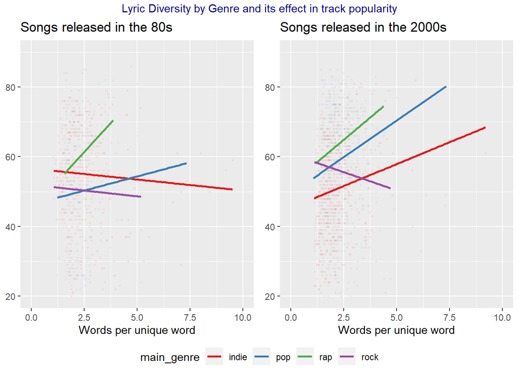

```r
attach(df_popular)

plot70s <- df_popular[(df_popular$main_genre %in% c('indie','rap', 'pop', 'rock') )
           &  (df_popular$decade == '70' )   ,]  %>%
  ggplot(aes(x = words_per_unique, y = track_popularity, color=main_genre)) +
  geom_point( alpha = 0.05, size=0.5) +
  geom_smooth( method ='lm', se = F, size=1) +
  scale_colour_brewer( palette = "Set1")+ xlim(0,10)+ ylim(20, 90) +
  xlab(label = 'Words per unique word') +
  ylab('Track popularity') +
  labs(title = 'Songs released in the 70s')

plot80s <- df_popular[(df_popular$main_genre %in% c('indie','rap', 'pop',  'rock') )
                      &  (df_popular$decade == '80' )          ,]  %>%
  ggplot(aes(x = words_per_unique, y = track_popularity, color=main_genre)) +
  geom_point( alpha = 0.05, size=0.5) +
  geom_smooth( method ='lm', se = F, size=1) +
  scale_colour_brewer( palette = "Set1")+ xlim(0,10)+ ylim(20, 90) +
  xlab(label = 'Words per unique word') +
  labs(title = 'Songs released in the 80s')


plot2000s <- df_popular[(df_popular$main_genre %in% c('indie','rap', 'pop',  'rock') )
                      &  (df_popular$decade == '00' )          ,]  %>%
  ggplot(aes(x = words_per_unique, y = track_popularity, color=main_genre)) +
  geom_point( alpha = 0.05, size=0.5) +
  geom_smooth( method ='lm', se = F, size=1) +
  scale_colour_brewer( palette = "Set1") + xlim(0,10) + ylim(20, 90) +
  xlab(label = 'Words per unique word') +
  labs(title = 'Songs released in the 2000s')


plot <- ggarrange(plot80s + rremove("ylab"),
          plot2000s + rremove("ylab"),
          ncol=2, nrow=1, common.legend = TRUE, legend="bottom")


annotate_figure(plot, top = text_grob("Lyric Diversity by Genre and its effect in track popularity",
                                      color = 'blue4',
                                      size = 11))
```

# 4. MODELING

## 4.1. PREDICTOR TO PLAY WITH RELEASE DATE

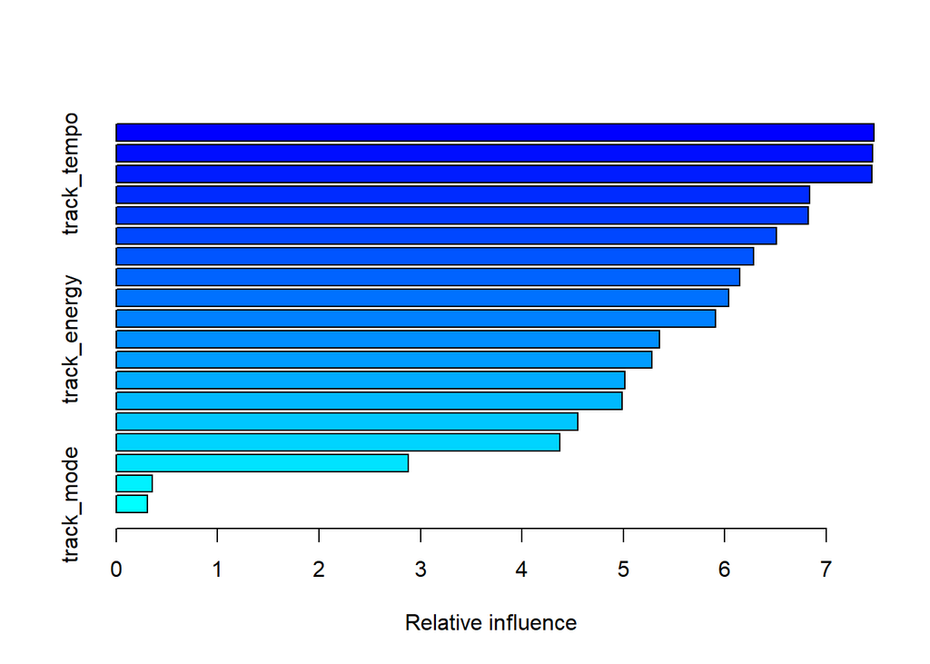

```
##                                           var   rel.inf
## track_loudness                 track_loudness 7.4690205
## main_genre                         main_genre 7.4529821
## track_tempo                       track_tempo 7.4478858
## words_per_unique             words_per_unique 6.8354529
## track_acousticeess         track_acousticeess 6.8215229
## track_valence                   track_valence 6.5095751
## duration_ms                       duration_ms 6.2803472
## track_liveness                 track_liveness 6.1452028
## track_speechiness           track_speechiness 6.0345756
## track_danceability         track_danceability 5.9088314
## track_energy                     track_energy 5.3526383
## unique_per_minute           unique_per_minute 5.2772452
## words_per_minute             words_per_minute 5.0156888
## decade                                 decade 4.9894615
## track_instrumentalness track_instrumentalness 4.5499611
## n_words                               n_words 4.3726852
## n_unique                             n_unique 2.8785977
## flg_explicit                     flg_explicit 0.3527533
## track_mode                         track_mode 0.3055727
```

```r
df_popular$flg_explicit = as.factor(flg_explicit)

df_popular$main_genre  = as.factor(main_genre )

attach(df_popular)

library(gbm)

boosted=gbm(track_popularity~duration_ms+
              flg_explicit+
              track_danceability+
              track_energy+
              track_loudness +
              track_mode +
              track_speechiness +
              track_acousticeess +
              track_instrumentalness +
              track_liveness +
              track_valence +
              track_tempo +
              decade +
              main_genre +
              n_words +
              n_unique  +
              unique_per_minute +
              words_per_minute +
              words_per_unique,
              data=df_popular,
              distribution= "gaussian",
            n.trees=10000,
            interaction.depth=4)

summary(boosted)
```

Words_per_unique, out entropy metric, makes it to the top 5 of important predictors.

```r
# write.table(df_popular[c(1,6,5500,2000,7000),
#                        names(df_popular)[!names(df_popular)
#                                          %in% c('lyrics_list',
#                                                 'genre_standarized',
#                                                 'artist_genres_list') ]],
#             "clipboard",
#             sep="\t")


predicted_score=predict(boosted, newdata=df_popular, n.trees=10000)
print('The average error of track popularity, from a 0-100 scale is:' )
```

```
## [1] "The average error of track popularity, from a 0-100 scale is:"
```

```r
mean(abs(predicted_score -track_popularity))
```

```
## [1] 5.183287
```

What does the model predict for…

… Wonderful Tonight: a 1970s ballad

```r
df_song = df_popular[df_popular$track_name == 'Wonderful Tonight' , ]
predicted_score_original=predict(boosted, newdata=df_song, n.trees=10000)
print(predicted_score_original)
```

```
## [1] 67.4249
```

```r
print(df_song)
```

```
## # A tibble: 1 x 45
## # Rowwise:
##   artist_id   track_id   album_id  duration_ms flg_explicit url       track_name
##   <chr>       <chr>      <chr>           <int> <fct>        <chr>     <chr>
## 1 6PAt558ZEZ~ 6zC0mpGYw~ 5MAL7e4E~      225026 False        https://~ Wonderful~
## # ... with 38 more variables: track_popularity <int>, track_type <chr>,
## #   track_danceability <dbl>, track_energy <dbl>, track_key <int>,
## #   track_loudness <dbl>, track_mode <int>, track_speechiness <dbl>,
## #   track_acousticeess <dbl>, track_instrumentalness <dbl>,
## #   track_liveness <dbl>, track_valence <dbl>, track_tempo <dbl>,
## #   track_release_date <chr>, artist_name.x <chr>, artist_genres.x <chr>,
## #   artist_followers.x <int>, artist_popularity.x <int>, lyrics <chr>, ...
```

```r
# what if we change its release to be 2020s
df_song$decade = 20

predicted_score_altered=predict(boosted, newdata=df_song, n.trees=10000)
print(predicted_score_altered)
```

```
## [1] 57.89857
```

Let’s repeat the analysis for a different type of song: Karma Chameleon

```r
#karma chameleon
df_song = df_popular[df_popular$track_name == 'Karma Chameleon' , ]
predicted_score_original=predict(boosted, newdata=df_song, n.trees=10000)
print(predicted_score_original)
```

```
## [1] 68.15044
```

```r
View(df_song)

df_song$decade = 20

predicted_score_altered=predict(boosted, newdata=df_song, n.trees=10000)
print(predicted_score_altered)
```

```
## [1] 61.96812
```

Interesting: the first one has its predicted score more affected if we simulate it as a 2020s song, while Karma Chameleon seems to be a tune that still adapts to today’s listeners.

## 4.2. PCA analysis at an Artist-Level

```r
df_artists_pca = df_popular %>% group_by(artist_name.x) %>%
  summarise(track_popularity = mean(track_popularity),
            track_danceability = mean(track_danceability),
            track_energy = mean(track_energy),
            track_instrumentalness = mean(track_instrumentalness),
            track_tempo = mean(track_tempo),
            duration_minutes = mean(duration_minutes),
            unique_per_minute = mean(unique_per_minute),
            words_per_unique = mean(words_per_unique),
            words_per_minute = mean(words_per_minute))

print(dim(df_artists_pca)
)
```

```
## [1] 3620   10
```